# Применение пакета mlr при разработке моделей

Заходякин Г.В., postlogist@gmail.com

15 мая 2017 г

```r
library(tidyverse) # трансформация и визуализация данных
library(mlr) # фреймворк для машинного обучения
library(stringr) # работа со строками
library(forcats) # работа с факторами
library(parallelMap) # распараллеливание задач
library(rpart.plot) # визуализация деревьев rpart
```

# Введение

При разработке модели для прогнозирования аналитик проходит через несколько этапов, показанных на рисунке.

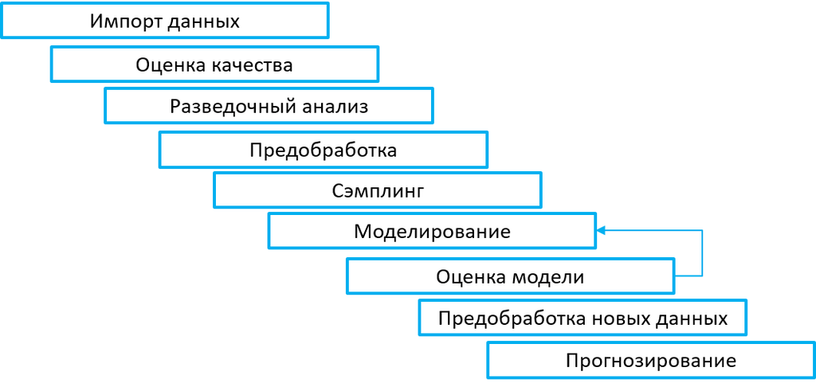

Этапы разработки и применения модели

Хотя каждая задача уникальна, последовательность этих этапов повторяется от задачи к задаче. В R можно найти многочисленные инструменты, полезные для реализации каждого этапа построения модели. Однако сложность состоит в большом разнообразии пакетов (на сегодня их свыше 10 000), которые разрабатывались независимо друг от друга, работают с разными объектами, имеют различный синтаксис и иногда концептуальную основу.

**Пример**: предсказание меток классов с использованием rpart и ctree

```r
# rpart:
predict(m_rpart, newdata = gr, type = "class")

# ctree:
predict(m_ctree, newdata = gr, type = "response")
```

Разнообразие подходов и необходимость чередования моделирования и рутинных операций (замена пропущенных значений, сэмплинг, оценка качества модели, сравнение моделей) замедляют работу аналитика и увеличивают риск ошибок. Кроме того, процесс обучения моделей часто является ресурсоемким и можно получить значительный выигрыш за счет использования параллельных вычислений.

В некоторых инструментах для разработки аналитических решений применяется “подход LEGO”, когда аналитику предлагается унифицированный набор блоков, реализующих операции трансформации набора данных, построения, оценки и применения модели.

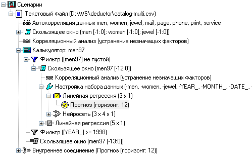

Сценарий в Deductor Studio

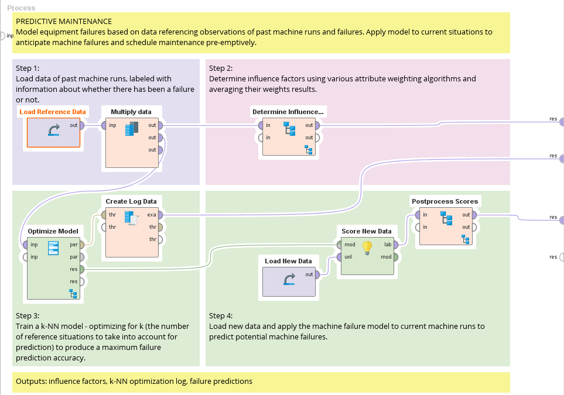

Сценарий в Rapidminer

Чтобы облегчить работу аналитика за счет унификации процесса подготовки данных, разработки, тестирования, сравнения и применения моделей, для R созданы специализированные пакеты-фреймворки, которые создают унифицированный интерфейс для работы с инструментами, реализованными в различных пакетах.

Наиболее известным пакетом, создающим среду для разработки моделей, является [caret](http://topepo.github.io/caret/index.html), разработанный Max Kuhn.

Более современной разработкой является пакет [mlr](http://mlr-org.github.io/) - Machine Learning in R, разработанный Bernd Bischl. В отличие от caret, этот пакет использует для визуализации результатов графическую систему ggplot2.

На рисунке показаны основные операции и объекты в процессе моделирования с помощью пакета mlr.

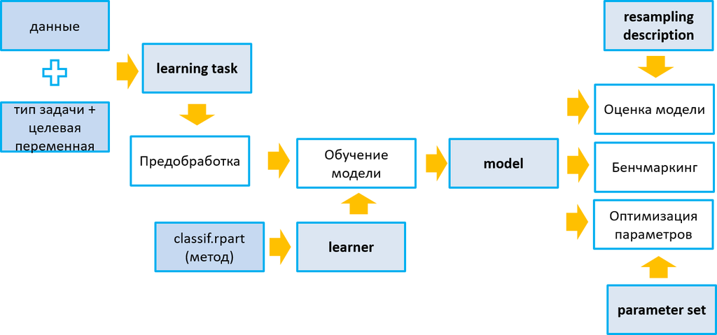

Этапы моделирования и объекты MLR

За счет унификации операций и автоматизации рутинных процедур, применение пакета mlr позволяет аналитику сконцентрироваться на решении прикладной задачи.

В этом блокноте будут показаны приемы подготовки данных, построения, оценки и оптимизации параметров моделей с помощью mlr.

# Пример решения задачи регрессии: прогнозирование цены подержанного автомобиля

## Загрузка данных и разведочный анализ

```r
car_ad <- read_csv("car_ad.csv")
glimpse(car_ad)
```

```
## Observations: 9,576
## Variables: 10
## $ car          <chr> "Ford", "Mercedes-Benz", "Mercedes-Benz", "Merced...
## $ price        <dbl> 15500.00, 20500.00, 35000.00, 17800.00, 33000.00,...
## $ body         <chr> "crossover", "sedan", "other", "van", "vagon", "c...
## $ mileage      <int> 68, 173, 135, 162, 91, 83, 199, 185, 146, 125, 0,...
## $ engV         <dbl> 2.5, 1.8, 5.5, 1.8, NA, 2.0, 2.0, 1.5, 1.8, 2.2, ...
## $ engType      <chr> "Gas", "Gas", "Petrol", "Diesel", "Other", "Petro...
## $ registration <chr> "yes", "yes", "yes", "yes", "yes", "yes", "yes", ...
## $ year         <int> 2010, 2011, 2008, 2012, 2013, 2013, 2003, 2011, 2...
## $ model        <chr> "Kuga", "E-Class", "CL 550", "B 180", "E-Class", ...
## $ drive        <chr> "full", "rear", "rear", "front", NA, "full", "fro...
```

Пропущенные значения

```r
car_ad %>%
  gather(key = "variable") %>%
  filter(is.na(value) | str_length(value) == 0) %>%
  group_by(variable) %>%
  summarize(missing = n())
```

```
## # A tibble: 2 x 2
##   variable missing
##      <chr>   <int>
## 1    drive     511
## 2     engV     434
```

В двух переменных имеются пропущенные значения, порядка 5% от общего количества наблюдений.

Переменные `car` (марка автомобиля) и `model` (модель автомобиля) содержат большое число категорий.

Наиболее популярные (более 100 объявлений о продаже) марки автомобилей:

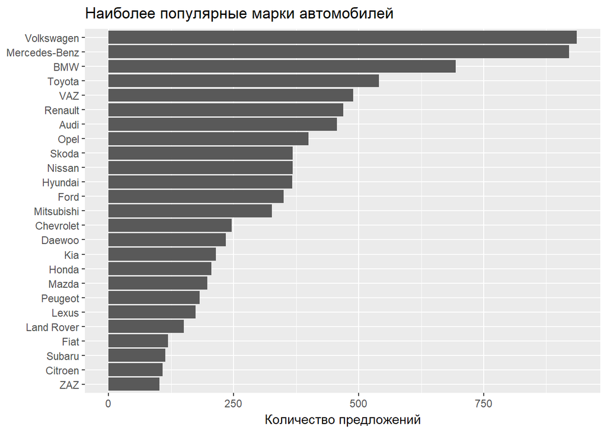

```r
car_ad %>%
  group_by(car) %>%
  summarize(count = n()) %>%
  arrange(count) %>%
  filter(count >= 100) %>%

  ggplot(aes(x = fct_inorder(car), y = count)) +
    geom_bar(stat = "identity") + coord_flip() +
  labs(x = NULL, y = "Количество предложений",
       title = "Наиболее популярные марки автомобилей")
```

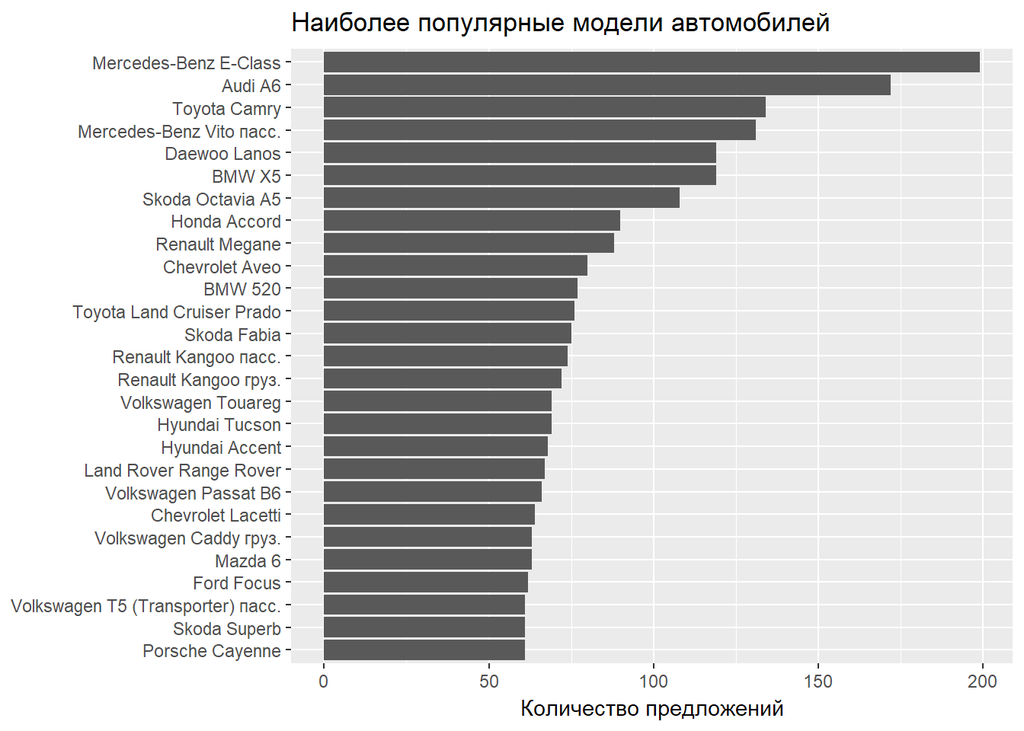

```r
car_ad1 <- car_ad %>%
  mutate(model = paste(car, model)) # объединяем производителя и модель для подписей


car_ad1 %>%
  group_by(model) %>%
  summarize(count = n()) %>%
  arrange(count) %>%
  filter(count > 60) %>%

  ggplot(aes(x = fct_inorder(model), y = count)) +
    geom_bar(stat = "identity") + coord_flip() +
    labs(x = NULL, y = "Количество предложений",
       title = "Наиболее популярные модели автомобилей")
```

Для моделирования необходимо преобразовать текстовые переменные в факторные. Уровни фактора будут определяться по частоте упоминания значений в наборе данных. Таким образом, в базовую категорию попадут наиболее типичные (частые) значения.

```r
# Преобразование текстовых переменных в факторные: mlr не работает с текстом
car_ad1 <- car_ad1 %>%
  mutate_if(is_character, fct_infreq)

glimpse(car_ad1)
```

```
## Observations: 9,576
## Variables: 10
## $ car          <fctr> Ford, Mercedes-Benz, Mercedes-Benz, Mercedes-Ben...
## $ price        <dbl> 15500.00, 20500.00, 35000.00, 17800.00, 33000.00,...
## $ body         <fctr> crossover, sedan, other, van, vagon, crossover, ...
## $ mileage      <int> 68, 173, 135, 162, 91, 83, 199, 185, 146, 125, 0,...
## $ engV         <dbl> 2.5, 1.8, 5.5, 1.8, NA, 2.0, 2.0, 1.5, 1.8, 2.2, ...
## $ engType      <fctr> Gas, Gas, Petrol, Diesel, Other, Petrol, Petrol,...
## $ registration <fctr> yes, yes, yes, yes, yes, yes, yes, yes, yes, yes...
## $ year         <int> 2010, 2011, 2008, 2012, 2013, 2013, 2003, 2011, 2...
## $ model        <fctr> Ford Kuga, Mercedes-Benz E-Class, Mercedes-Benz ...
## $ drive        <fctr> full, rear, rear, front, NA, full, front, front,...
```

После преобразования текста в факторы становится доступна описательная статистика по всем переменным.

```r
summary(car_ad1)
```

```
##             car           price               body         mileage
##  Volkswagen   : 936   Min.   :     0   sedan    :3646   Min.   :  0.0
##  Mercedes-Benz: 921   1st Qu.:  4999   crossover:2069   1st Qu.: 70.0
##  BMW          : 694   Median :  9200   hatch    :1252   Median :128.0
##  Toyota       : 541   Mean   : 15633   van      :1049   Mean   :138.9
##  VAZ          : 489   3rd Qu.: 16700   other    : 838   3rd Qu.:194.0
##  Renault      : 469   Max.   :547800   vagon    : 722   Max.   :999.0
##  (Other)      :5526
##       engV          engType     registration      year
##  Min.   : 0.100   Petrol:4379   yes:9015     Min.   :1953
##  1st Qu.: 1.600   Diesel:3013   no : 561     1st Qu.:2004
##  Median : 2.000   Gas   :1722                Median :2008
##  Mean   : 2.646   Other : 462                Mean   :2007
##  3rd Qu.: 2.500                              3rd Qu.:2012
##  Max.   :99.990                              Max.   :2016
##  NA's   :434
##                       model        drive
##  Mercedes-Benz E-Class   : 199   front:5188
##  Audi A6                 : 172   full :2500
##  Toyota Camry            : 134   rear :1377
##  Mercedes-Benz Vito пасс.: 131   NA's : 511
##  BMW X5                  : 119
##  Daewoo Lanos            : 119
##  (Other)                 :8702
```

Распределения количественных переменных скошенные. В данных по объему двигателя содержатся странные значения - порядка 100 литров.

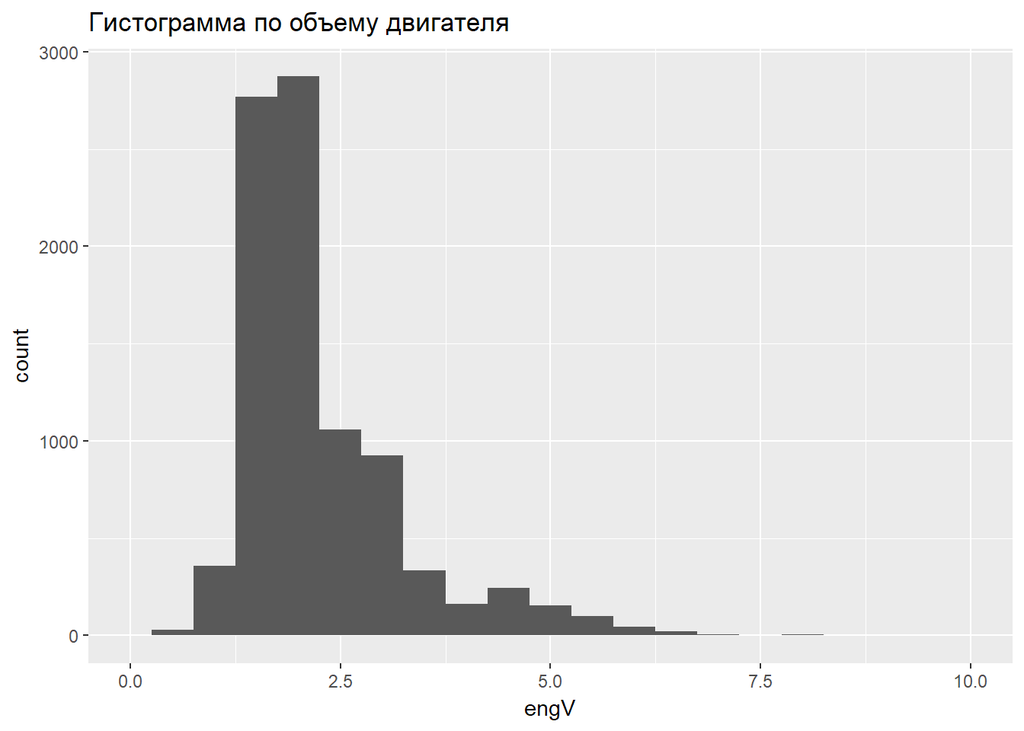

```r
ggplot(car_ad1, aes(x = engV)) +
  geom_histogram(binwidth = 0.5) +
  xlim(c(0, 10)) +
  labs(title = "Гистограмма по объему двигателя")
```

```r
car_ad1 %>%
  filter(engV > 10) %>%
  arrange(engV) %>%
  head(10)
```

```
## # A tibble: 10 x 10
##        car price   body mileage  engV engType registration  year
##     <fctr> <dbl> <fctr>   <int> <dbl>  <fctr>       <fctr> <int>
##  1    Opel  9100  sedan     147  11.5  Petrol          yes  2008
##  2     GAZ 15000  sedan       1  12.0  Petrol          yes  1962
##  3    Opel  5700  sedan     135  14.0  Petrol          yes  2005
##  4 Citroen  1650    van     180  14.0  Petrol           no  2006
##  5 Renault  4800    van     113  15.0  Diesel          yes  2006
##  6    Opel  3000  sedan     276  17.0  Diesel          yes  1993
##  7 Hyundai 14850  sedan      75  18.0     Gas          yes  2012
##  8   Skoda  8200  sedan       1  18.0     Gas          yes  2005
##  9    Audi  1950  sedan     320  19.0   Other           no  1996
## 10 Renault  2950  vagon     280  19.0  Diesel          yes  2000
## # ... with 2 more variables: model <fctr>, drive <fctr>
```

Двигатель объемом 17 литров на легковом автомобиле - очевидно некорректные данные - следствие ошибок ввода или преобразования единиц измерения. Заменим все неправдоподобные значения на пропущенные. Кроме того, отфильтруем предложения с нулевой ценой. Поскольку зависимость пробег - цена - нелинейна (цена обратно пропорциональна пробегу), добавим переменную: 1/пробег.

```r
car_ad1 <-  car_ad1 %>%
  filter(price > 0) %>%
  mutate(inv_mileage = 1000 / (mileage + 1),
         engV = if_else(engV > 8, as.numeric(NA), engV))
```

## Моделирование с помощью MLR

### Шаг 1. Создание задачи для обучения (learning task)

Задача для обучения (**learning task**) в mlr - это “обертка” над таблицей данных, включающая дополнительные атрибуты, например - указание целевой переменной (**target**), типа задачи обучения - регрессия, классификация, метку для набора данных, которая используется в отчетах по сравнению моделей и на визуализациях.

Для создания задач регрессии используется функция `makeRegrTask()`.

```r
car_task <- makeRegrTask(id = "Цены автомобилей",
                         data = car_ad1, target = "price",
                         fixup.data = "warn")
print(car_task)
```

```
## Supervised task: Цены автомобилей
## Type: regr
## Target: price
## Observations: 9309
## Features:
## numerics  factors  ordered
##        4        6        0
## Missings: TRUE
## Has weights: FALSE
## Has blocking: FALSE
```

Полученный объект содержит таблицу данных и необходимую для других функций пакета информацию о задаче. В mlr есть большое количество функций, позволяющих работать с задачей моделирования - получать о ней информацию, или модифицировать.

Например, можно получить размер таблицы данных:

```r
getTaskSize(car_task)
```

```
## [1] 9309
```

### Шаг 2. Создание алгоритма для обучения - “ученика” (learner)

В mlr встроены несколько десятков алгоритмов для решения задач классификации и регрессии. Список этих алгоритмов можно получить с помощью функции `listLearners()` или в документации пакета - [Available Learners](https://mlr-org.github.io/mlr-tutorial/release/html/integrated_learners/index.html)

```r
listLearners(obj = "regr") %>%
  select(name, class) %>%
  arrange(str_length(name)) %>%
  head(10) %>%
  arrange(name)
```

```
##              name                class
## 1   Bayesian CART           regr.bcart
## 2          Cubist          regr.cubist
## 3   Decision Tree           regr.rpart
## 4         h2o.gbm         regr.h2o.gbm
## 5         h2o.glm         regr.h2o.glm
## 6         Kriging              regr.km
## 7  Neural Network            regr.nnet
## 8    Node Harvest     regr.nodeHarvest
## 9   Random Forest    regr.randomForest
## 10  Random Forest regr.randomForestSRC
```

В столбце `class` содержится класс-обертка для алгоритма, который необходимо указать в функции для создания алгоритма обучения - `makeLearner()`. Помимо названия, в таблице содержатся и атрибуты алгоритмов - например, можно ли с помощью данного алгоритма оценивать вероятность или стандартную ошибку для прогноза. Эти атрибуты можно использовать для автоматического отбора алгоритмов с нужными свойствами.

Общее количество алгоритмов регрессии в mlr:

```r
listLearners(obj = "regr") %>% count()
```

```
## # A tibble: 1 x 1
##       n
##   <int>
## 1    64
```

Создадим алгоритм обучения на основе множественной линейной регрессии

```r
lrn_lm <- makeLearner("regr.lm", id = "Линейная регрессия")
lrn_lm
```

```
## Learner Линейная регрессия from package stats
## Type: regr
## Name: Simple Linear Regression; Short name: lm
## Class: regr.lm
## Properties: numerics,factors,se,weights
## Predict-Type: response
## Hyperparameters:
```

В метаданных полученного объекта содержатся сведения о типе алгоритма, свойствах, типе прогноза по умолчанию и гиперпараметрах.

**Гиперпараметры** - это настройки алгоритма обучения модели. Например, параметры в модели линейной регрессии - это коэффициенты для переменных. А гиперпараметром может быть величина штрафа для регуляризации коэффициентов в модели ридж- или лассо-регрессии.

### Шаг 3. Предобработка

Предобработка - это приведение набора данных к виду, пригодному и оптимальному для моделирования.

Примерами операций предобработки являются:

- удаление переменных
- обработка пропущенных переменных
- фильтрация выборосов
- удаление переменных, содержащих одинаковые значения

Лишние столбцы можно удалить с помощью функции `dropFeatures()`.

На этапе разведочного анализа мы выяснили, что марка и модель машины содержат большое число категорий. Эти переменные безусловно влияют на цену, однако включение их в модель вызовет ряд проблем:

- модель получится слишком сложной (каждая категория будет учитываться как фиктивная переменная)
- при разбиении на обучающее/тестовое множества малочисленные категории могут не попасть в обучающее множество, тогда при попытке прогнозирования будет выдаваться сообщение об ошибке

В связи с этим, мы объединим все малочисленные категории в одну - “.other”

```r
car_task <- car_task %>%
  mergeSmallFactorLevels(min.perc = 0.015, new.level = ".other")
```

Более подробно о проблеме новых значений факторов при прогнозировании написано здесь: https://github.com/mlr-org/mlr/issues/811

Выбросы (некорректные значения объема двигателя и цены) мы уже удалили стандартными средствами до создания задачи. Однако в mlr также имеются функции, облегчающие борьбу с выбросами (см. http://mlr-org.github.io/mlr-tutorial/release/html/preproc/index.html)

Многие модели не могут работать с пропущенными значениями. Например, попытка обучить модель регрессии на данных с NA приведет к ошибке.

```r
#m_lm <- train(car_lm, car_task) # не работает из-за NA
```

Пропущенные значения можно отфильтровать или заменить на “типичные” или специальные значения. В mlr для автоматической замены пропусков используется функция `impute()`.

Для категориальных признаков заменим пропущенные значения на константу “Unknown”, для количественных признаков - на среднее значение:

```r
car_imputation <- car_task %>%
  impute(classes = list(numeric = imputeMean(), factor = imputeConstant("Unknown")))

car_imputation
```

```
## $task
## Supervised task: Цены автомобилей
## Type: regr
## Target: price
## Observations: 9309
## Features:
## numerics  factors  ordered
##        4        6        0
## Missings: FALSE
## Has weights: FALSE
## Has blocking: FALSE
##
## $desc
## Imputation description
## Target: price
## Features: 10; Imputed: 8
## impute.new.levels: TRUE
## recode.factor.levels: TRUE
## dummy.type: factor
```

В объекте, полученном от `impute()` содержится набор данных (`task`) с замененными значениями, а также описание стратегии обработки пропущенных значений (`desc`), которое можно применить к новому набору данных при прогнозировании.

Для удобства, извлечем в отдельную переменную набор данных с замененными пропусками.

```r
car_imputed <- car_imputation$task
```

### Шаг 4. Обучение модели

Для обучения любых моделей используется функция `train()`. При необходимости, можно задать дополнительные параметры алгоритма, или тип прогноза (например, для моделей классификации - метки классов, или вероятности)

```r
m_lm <- train(lrn_lm, car_imputed)
m_lm
```

```
## Model for learner.id=Линейная регрессия; learner.class=regr.lm
## Trained on: task.id = Цены автомобилей; obs = 9309; features = 10
## Hyperparameters:
```

Из полученного объекта можно извлечь метаданные и саму модель. После этого можно работать с моделью стандартными средствами, например посмотреть коэффициенты с помощью функции summary()

```r
m_lm %>%
  getLearnerModel() %>%
  summary()
```

```
##
## Call:
## stats::lm(formula = f, data = d)
##
## Residuals:
##    Min     1Q Median     3Q    Max
## -72477  -5662   -245   3998 444719
##
## Coefficients:
##                    Estimate Std. Error t value Pr(>|t|)
## (Intercept)      -1.545e+06  6.592e+04 -23.443  < 2e-16 ***
## carMercedes-Benz  8.256e+03  9.691e+02   8.520  < 2e-16 ***
## carBMW            3.091e+03  1.012e+03   3.055 0.002260 **
## carToyota        -2.461e+03  9.821e+02  -2.506 0.012245 *
## carVAZ           -3.012e+03  1.042e+03  -2.890 0.003865 **
## carRenault       -2.992e+03  9.932e+02  -3.012 0.002599 **
## carAudi           1.441e+03  1.212e+03   1.189 0.234624
## carOpel           1.067e+03  1.038e+03   1.028 0.304091
## carNissan        -5.366e+03  1.099e+03  -4.881 1.07e-06 ***
## carSkoda         -2.049e+03  1.090e+03  -1.881 0.060016 .
## carHyundai       -6.281e+03  1.097e+03  -5.725 1.06e-08 ***
## carFord          -2.385e+03  1.096e+03  -2.177 0.029537 *
## carMitsubishi    -5.611e+03  1.140e+03  -4.920 8.79e-07 ***
## carChevrolet     -3.383e+03  1.266e+03  -2.671 0.007569 **
## carDaewoo        -3.560e+03  1.299e+03  -2.739 0.006165 **
## carKia           -4.793e+03  1.320e+03  -3.633 0.000282 ***
## carHonda         -2.701e+03  1.350e+03  -2.001 0.045430 *
## carMazda         -3.302e+03  1.377e+03  -2.399 0.016469 *
## carPeugeot       -2.707e+03  1.397e+03  -1.938 0.052666 .
## carLexus         -4.964e+03  1.514e+03  -3.278 0.001049 **
## car.other         2.886e+02  7.708e+02   0.374 0.708145
## bodycrossover    -2.015e+03  7.466e+02  -2.699 0.006972 **
## bodyhatch         6.819e+02  6.010e+02   1.135 0.256607
## bodyvan          -3.188e+03  7.405e+02  -4.306 1.68e-05 ***
## bodyother        -2.596e+02  6.913e+02  -0.376 0.707248
## bodyvagon        -9.087e+02  7.538e+02  -1.205 0.228051
## mileage          -2.895e+01  2.465e+00 -11.744  < 2e-16 ***
## engV              9.918e+03  2.532e+02  39.172  < 2e-16 ***
## engTypeDiesel     2.343e+03  5.158e+02   4.543 5.61e-06 ***
## engTypeGas       -2.430e+03  5.050e+02  -4.812 1.52e-06 ***
## engTypeOther      2.299e+03  8.716e+02   2.637 0.008369 **
## registrationno   -6.784e+03  8.094e+02  -8.381  < 2e-16 ***
## year              7.647e+02  3.277e+01  23.334  < 2e-16 ***
## modelAudi A6      3.722e+03  2.214e+03   1.681 0.092810 .
## model.other       7.155e+03  1.448e+03   4.943 7.83e-07 ***
## drivefull         6.726e+03  7.392e+02   9.100  < 2e-16 ***
## driverear        -2.511e+02  7.175e+02  -0.350 0.726345
## driveUnknown     -8.148e+02  8.427e+02  -0.967 0.333609
## inv_mileage       3.274e+01  1.021e+00  32.073  < 2e-16 ***
## ---
## Signif. codes:  0 '***' 0.001 '**' 0.01 '*' 0.05 '.' 0.1 ' ' 1
##
## Residual standard error: 17040 on 9270 degrees of freedom
## Multiple R-squared:  0.5106, Adjusted R-squared:  0.5086
## F-statistic: 254.5 on 38 and 9270 DF,  p-value: < 2.2e-16
```

### Шаг 5. Оценка качества модели

#### Разбиение на подвыборки “вручную”

Оценку качества моделей необходимо проводить на новых данных. В связи с этим, при обучении необходимо разделять набор данных на обучающую и тестовую подвыборки.

Можно сделать это вручную, используя функцию `subsetTask()` для отбора строк из задачи, или же можно указать, какое подмножество строк использовать для обучения модели непосредственно в функции `train()`

Воспользуемся вторым подходом

```r
# Получаем номера строк для обучающей и тестовой выборки
set.seed(123) # для воспроизводимости
car_n <- getTaskSize(car_task) # количество строк в таблице
car_train <- sample(car_n, size = car_n * 0.7) # случайный отбор номеров строк в обучающую выборку
car_test <- base::setdiff(1:car_n, car_train) # все остальные номера пойдут в тестовую выборку

# Строим модель только на тестовой выборке
car_mod_lm <- train(lrn_lm, task = car_imputed,
                    subset = car_train)
```

Теперь можно построить прогноз на тестовой выборке:

```r
car_pred_lm <- predict(car_mod_lm,
                       task = car_imputed,
                       subset = car_test)

car_pred_lm
```

```
## Prediction: 2793 observations
## predict.type: response
## threshold:
## time: 0.02
##    id truth  response
## 2   2 20500 10972.149
## 3   3 35000 55074.574
## 4   4 17800 21399.553
## 12 12 20400 10440.605
## 13 13 22500 12005.368
## 14 14  4700  7359.726
## ... (2793 rows, 3 cols)
```

Рассчитать показатели ошибки можно с помощью функции `performance()`. Чтобы не перечислять их каждый раз, создадим список нужных показателей - `reg_ms`

```r
reg_ms <- list(rmse, mape, mae)

performance(car_pred_lm,
            measures = reg_ms) %>%
  round(2)
```

```
##     rmse     mape      mae
## 16912.89     1.18  8434.55
```

Модель получилась довольно плохой: MAPE = 118%.

#### Автоматизация оценки качества модели

Поскольку оценка качства модели на тестовом множестве - востребованная операция, mlr позволяет автоматизировать ее. Вначале надо указать стратегию сэмплинга (разделения на подвыборки), используя функцию `makeResampleDesc()`.

```r
car_rdesc <- makeResampleDesc(method = "Holdout",
                              split = 0.8,
                              stratify.cols = "car")
car_rdesc
```

```
## Resample description: holdout with 0.80 split rate.
## Predict: test
## Stratification: FALSE
```

Стратификация - это подвыборка внутри заданных групп, обеспечивающая одинаковое соотношение групп в обучающей и тестовой подвыборках. В данном случае мы обеспечиваем одинаковые доли производителей в обучающей и тестовой выборках.

**Замечание:** в задачах классификации может оказаться полезным другой способ стратификации, который обеспечивает одинаковые доли классов в обучающей и тестовой выборках, т.е. стратификация проводится по целевой переменной. Этот способ можно выбрать при помощи параметра `stratify = TRUE`.

После этого можно проверить качество модели автоматически, с помощью функции `resample()`:

```r
set.seed(123)
resample(learner = lrn_lm,
         resampling = car_rdesc,
         task = car_imputed,
         measures = reg_ms)
```

```
## [Resample] holdout iter 1: rmse.test.rmse=1.23e+04,mape.test.mean=1.19,mae.test.mean=7.8e+03
## [Resample] Aggr. Result: rmse.test.rmse=1.23e+04,mape.test.mean=1.19,mae.test.mean=7.8e+03
```

```
## Resample Result
## Task: Цены автомобилей
## Learner: Линейная регрессия
## Aggr perf: rmse.test.rmse=1.23e+04,mape.test.mean=1.19,mae.test.mean=7.8e+03
## Runtime: 0.0713971
```

Еще одной популярной стратегией сэмплинга является кросс-валидация (или скользящий контроль), при которой набор данных разбивается на $k$ блоков, а затем каждый из блоков выбирается в качестве тестовой выборки, а остальные блоки - в качестве обучающей выборки. Таким образом, модель обучается и проверятеся $k$ раз. Затем проводится усреднение показателей в каждом из повторов.

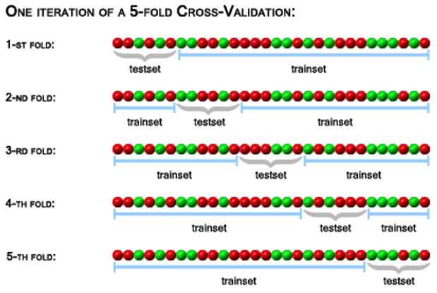

Кросс-валидация

Применим 10-блочную кросс-валидацию для оценки качества модели

```r
car_rdesc_cv <- makeResampleDesc(method = "CV",
                                 iters = 10,
                                 stratify.cols = "car")
set.seed(123)

resample(learner = lrn_lm,
         resampling = car_rdesc_cv,
         task = car_imputed,
         measures = reg_ms,
         show.info = TRUE)
```

```
## [Resample] cross-validation iter 1: rmse.test.rmse=1.86e+04,mape.test.mean=1.16,mae.test.mean=8.11e+03
## [Resample] cross-validation iter 2: rmse.test.rmse=1.67e+04,mape.test.mean=1.14,mae.test.mean=8.37e+03
## [Resample] cross-validation iter 3: rmse.test.rmse=1.61e+04,mape.test.mean=0.939,mae.test.mean=8.45e+03
## [Resample] cross-validation iter 4: rmse.test.rmse=1.33e+04,mape.test.mean=1.22,mae.test.mean=7.63e+03
## [Resample] cross-validation iter 5: rmse.test.rmse=1.97e+04,mape.test.mean=1.11,mae.test.mean=8.6e+03
## [Resample] cross-validation iter 6: rmse.test.rmse=1.63e+04,mape.test.mean=1.01,mae.test.mean=8.98e+03
## [Resample] cross-validation iter 7: rmse.test.rmse=1.45e+04,mape.test.mean= 1.1,mae.test.mean=8.03e+03
## [Resample] cross-validation iter 8: rmse.test.rmse=1.69e+04,mape.test.mean=1.27,mae.test.mean=7.73e+03
## [Resample] cross-validation iter 9: rmse.test.rmse=1.58e+04,mape.test.mean=1.02,mae.test.mean=8.29e+03
## [Resample] cross-validation iter 10: rmse.test.rmse=2.13e+04,mape.test.mean= 1.2,mae.test.mean=8.96e+03
## [Resample] Aggr. Result: rmse.test.rmse=1.71e+04,mape.test.mean=1.11,mae.test.mean=8.31e+03
```

```
## Resample Result
## Task: Цены автомобилей
## Learner: Линейная регрессия
## Aggr perf: rmse.test.rmse=1.71e+04,mape.test.mean=1.11,mae.test.mean=8.31e+03
## Runtime: 0.748119
```

### Шаг 6. Прогнозирование

Применить модель к новым данным можно с помощью функции `predict()`.

Если к исходным данным для построения модели применялась предобработка, то такая же предобработка должна применяться и к новым данным. Это обеспечивается функцией `reimpute()`, которая применяет к данным описание предобработки, созданное функцией `impute()`.

Кроме того нужно убедиться, что кодирование уровней фактора такое же, как и в исходных данных.

```r
# Новый автомобиль
new_car2 <- tibble(car = "Ford", body = "crossover",
              mileage = 10L, engV = 2.7,
              inv_mileage = 1000 / (10 + 1),
              engType = "Gas", registration = "yes",
              year = 2012L, drive = "full", model = ".other"
              )

# Применение стратегии предобработки
new_car2_imp <- new_car2 %>%
  mutate_if(is.character, as.factor) %>%
  reimpute(desc = car_imputation$desc)

# В данном случае, разницы нет, т.к. пропущенных значений в новых данных нет
predict(car_mod_lm, newdata = new_car2)
```

```
## Prediction: 1 observations
## predict.type: response
## threshold:
## time: 0.00
##   response
## 1 29056.84
```

```r
predict(car_mod_lm, newdata = new_car2_imp)
```

```
## Prediction: 1 observations
## predict.type: response
## threshold:
## time: 0.00
##   response
## 1 29056.84
```

### Визуализация прогнозов

Для оценки адекватности модели полезно анализировать прогнозы визуально. В пакете mlr есть возможность проверить, как работает выбранный алгоритм в текущей задаче. При этом производится построение и оценка модели на основе 1 или 2 выбранных атрибутов.

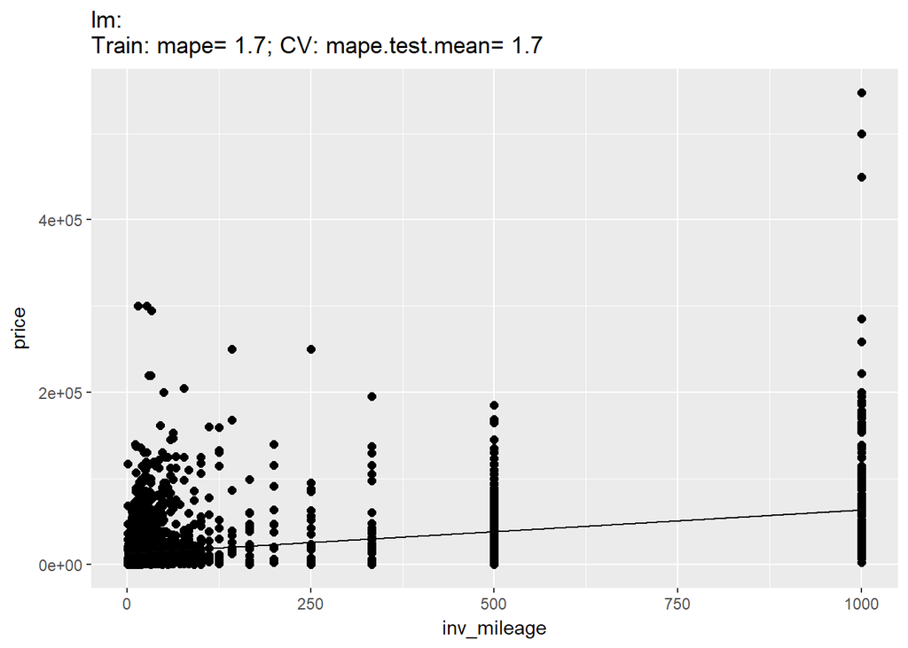

```r
plotLearnerPrediction(lrn_lm, task = car_imputed,
                      features = "inv_mileage",
                      measures = mape)
```

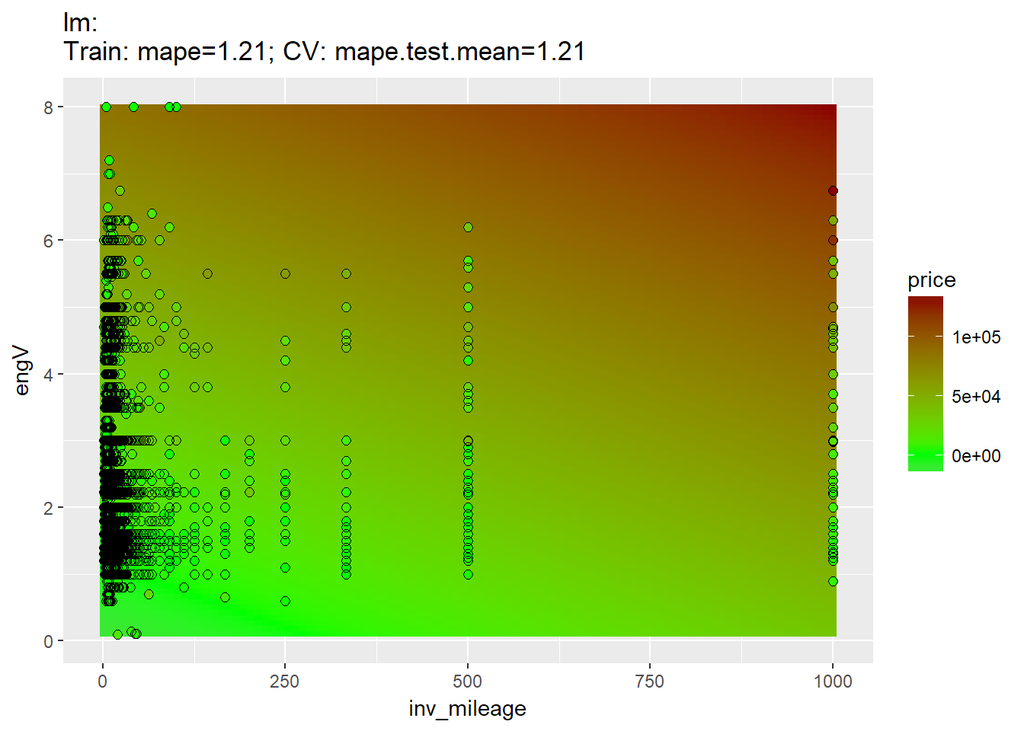

```r
plotLearnerPrediction(lrn_lm, task = car_imputed,
                      features = c("inv_mileage", "engV"),
                      measures = mape)
```

### Сравнение моделей

Сравним несколько алгоритмов для решения задач регрессии - линейную регрессию (lm), ридж-регрессию (glmnet), и два вида деревьев - rpart и ctree.

Функция `makeLearners()` позволяет создать сразу несколько алгоритмов прогнозирования и сохранить их в один список. Такой список можно в дальнейшем дополнять другими моделями.

```r
car_learners <- makeLearners(
  c("lm", "glmnet", "rpart", "ctree"),
  ids = c("lm", "glmnet", "rpart", "ctree"),
  type = "regr")
```

Одним из вариантов сравнения моделей является обработка полученного списка алгоритмов с помощью функции `lapply()`. Эта функция позволяет применить к каждому элементу списка заданную функцию. В нашем случае - это функция обучения модели `train()`. Результаты сохраняются в новый список.

```r
car_models <- car_learners %>%
  lapply(train, task = car_imputed)
```

Сравним графически работу разных моделей, использующих пару предикторов - 1/пробег и объем двигателя:

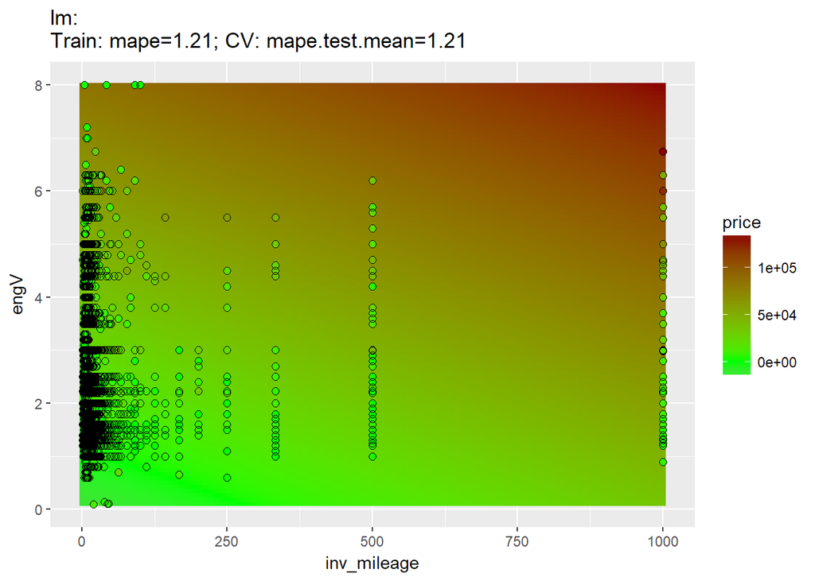

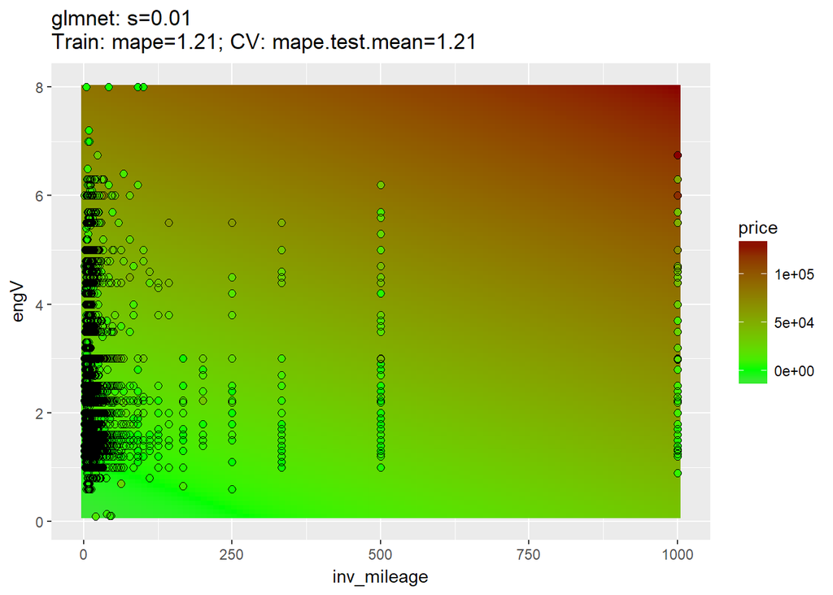

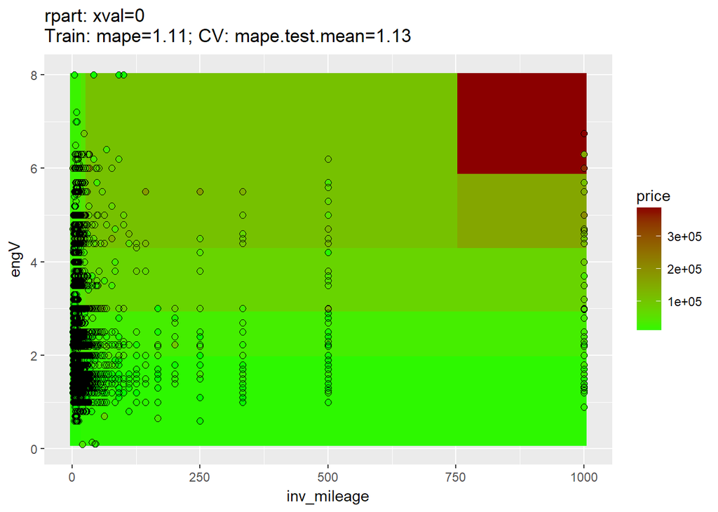

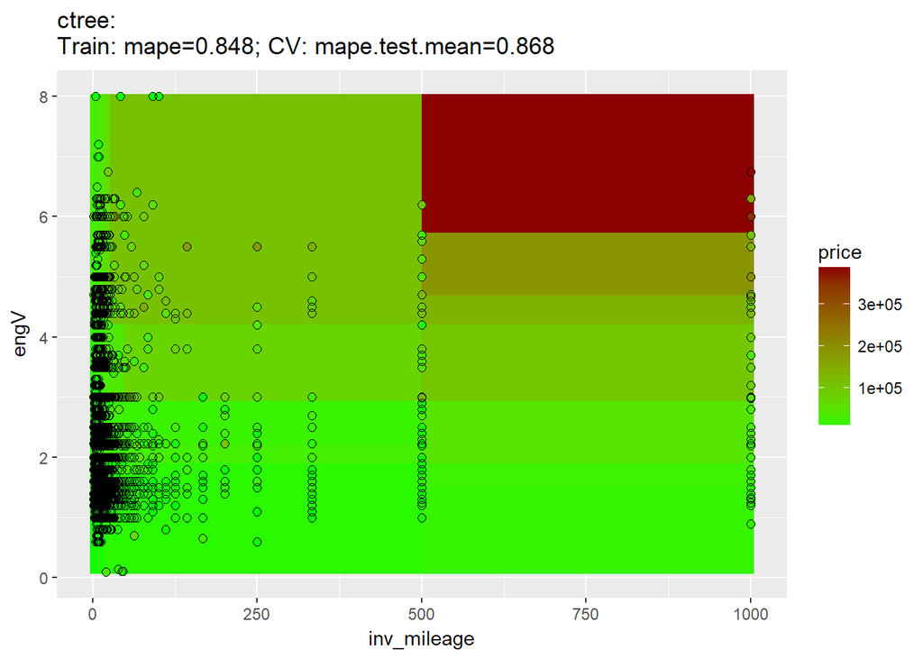

```r
car_learners %>%
  lapply(plotLearnerPrediction,
         task = car_imputed,
         features = c("inv_mileage", "engV"),
         measures = mape)
```

Наилучшие результаты получены при использовании дерева ctree.

Количественно оценить ошибку моделей можно с помощью функции `resample()`. Чтобы обработать сразу весь список, можно воспользоваться функцией `lapply()`:

```r
set.seed(123)
car_learners %>%
  lapply(resample, task = car_imputed,
         resampling = car_rdesc_cv,
         measures = reg_ms,
         show.info = FALSE)
```

Однако существует более удобный и эффективный метод сравнения моделей - применение функции `benchmark()`. Данная функция позволяет применить несколько алгоритмов обучения к нескольким наборам данных (по списку), при этом автоматически выполняется ресемплинг. Для ускорения расчетов можно распараллелить вычисления на несколько ядер процессора.

```r
set.seed(123, "L'Ecuyer") # При использовании параллельных вычислений необходимо выбирать алгоритм генерации СЧ "L'Ecuyer"

# Определение количества доступных ядер процессора
num_cores <- parallel::detectCores()

# Запуск параллельных вычислений
parallelStartSocket(num_cores) # для Windows
```

```
## Starting parallelization in mode=socket with cpus=8.
```

```r
car_bench <- car_learners %>%
  benchmark(tasks = car_imputed,
         resampling = car_rdesc_cv,
         measures = append(list(timetrain), reg_ms),
         show.info = FALSE)
```

```
## Exporting objects to slaves for mode socket: .mlr.slave.options
```

```
## Mapping in parallel: mode = socket; cpus = 8; elements = 4.
```

```r
# Остановка параллельных вычислений
parallelStop()
```

```
## Stopped parallelization. All cleaned up.
```

Результаты сравнения моделий (benchmarking results) сохранены в объект `car_bench`. Их можно преобразовать в табличный вид и визуализировать:

```r
car_bench %>%
  getBMRAggrPerformances(as.df = TRUE) %>%
  arrange(mape.test.mean) %>%
  select(learner.id, mape.test.mean, timetrain.test.mean)
```

```
##   learner.id mape.test.mean timetrain.test.mean
## 1      ctree      0.2790849               1.187
## 2      rpart      0.7384870               0.093
## 3     glmnet      1.1097977               0.138
## 4         lm      1.1140575               0.117
```

Визуализация результатов:

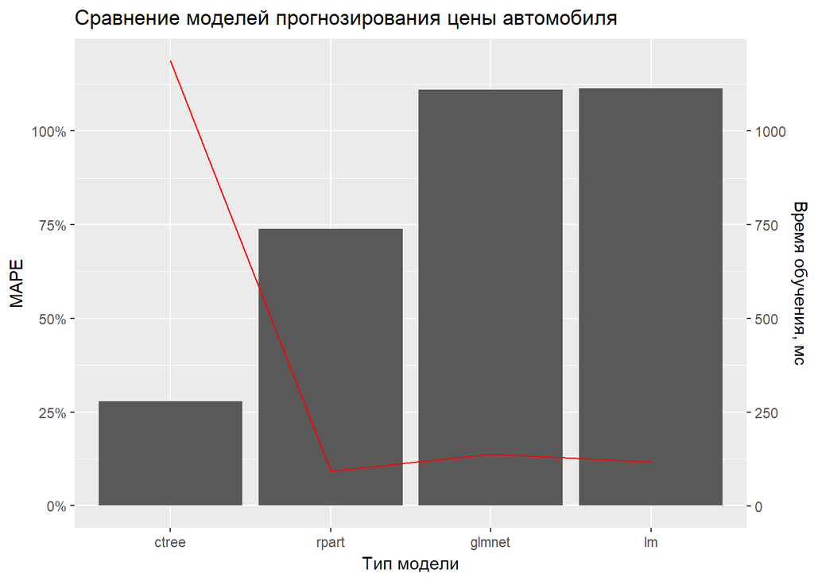

```r
car_bench %>%
  getBMRAggrPerformances(as.df = TRUE) %>%
  arrange(mape.test.mean) %>%
  ggplot(aes(x = fct_inorder(learner.id),
             y = mape.test.mean)) +
  geom_bar(stat = "identity") +
  geom_line(aes(y = timetrain.test.mean, group = 1),
            color = "red") +
  scale_y_continuous(labels = scales::percent,
                     sec.axis = sec_axis(~ . * 1000,
                                         name = "Время обучения, мс")) +
  labs(title = "Сравнение моделей прогнозирования цены автомобиля",
       x = "Тип модели", y = "MAPE")
```

Самым точным алгоритмом оказался ctree, а самым быстрым - rpart.

См. также https://mlr-org.github.io/mlr-tutorial/release/html/benchmark_experiments/index.html

# Задача классификации

## Загрузка данных и разведочный анализ

В этом разделе мы применим пакет mlr для обучения моделей классификации. В качестве примера используем уже рассмотренную ранее задачу предсказания оттока сотрудников (../decision-trees/decision-trees.Rmd).

Загрузка исходных данных

```r
turnover <- readRDS("turnover.RDS")
head(turnover)
```

```
## # A tibble: 6 x 10
##   satisfaction_level last_evaluation number_project average_monthly_hours
##                <dbl>           <dbl>          <dbl>                 <dbl>
## 1                6.9             5.9              4                   266
## 2                6.8             5.4              4                   146
## 3                5.9             5.8              2                   267
## 4                7.3             6.1              4                   260
## 5                4.9             4.0              2                   148
## 6                8.6             9.8              3                   158
## # ... with 6 more variables: time_in_company <dbl>, work_accident <fctr>,
## #   left <fctr>, promotion_last_5years <fctr>, department <fctr>,
## #   salary <fctr>
```

Визуализация зависимости целевой переменной от уровня удовлетворенности, загруженности и уровня компетентности сотрудника

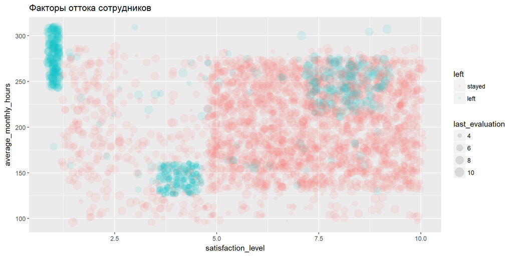

```r
turnover %>%
  ggplot(aes(x = satisfaction_level,
             y = average_monthly_hours,
             color = left,
             size = last_evaluation )) +
  geom_jitter(alpha = 0.1) +
  labs(title = "Факторы оттока сотрудников")
```

Распределения переменных и техническое качество данных

```r
summary(turnover)
```

```
##  satisfaction_level last_evaluation  number_project  average_monthly_hours
##  Min.   : 0.90      Min.   : 3.600   Min.   :2.000   Min.   : 96.0
##  1st Qu.: 4.50      1st Qu.: 5.600   1st Qu.:3.000   1st Qu.:158.0
##  Median : 6.50      Median : 7.300   Median :4.000   Median :202.0
##  Mean   : 6.17      Mean   : 7.191   Mean   :3.819   Mean   :202.3
##  3rd Qu.: 8.20      3rd Qu.: 8.700   3rd Qu.:5.000   3rd Qu.:246.0
##  Max.   :10.00      Max.   :10.000   Max.   :7.000   Max.   :310.0
##
##  time_in_company  work_accident     left      promotion_last_5years
##  Min.   : 2.000   no :2598      stayed:2301   no :2946
##  1st Qu.: 3.000   yes: 402      left  : 699   yes:  54
##  Median : 3.000
##  Mean   : 3.529
##  3rd Qu.: 4.000
##  Max.   :10.000
##
##        department     salary
##  sales      :790   low   :1474
##  technical  :552   medium:1255
##  support    :448   high  : 271
##  IT         :259
##  product_mng:180
##  accounting :172
##  (Other)    :599
```

Пропущенных значений нет

## Создание задачи обучения

```r
turnover_task <- makeClassifTask(id = "Отток",
                                 data = turnover,
                                 target = "left",
                                 positive = "left")
turnover_task
```

```
## Supervised task: Отток
## Type: classif
## Target: left
## Observations: 3000
## Features:
## numerics  factors  ordered
##        5        4        0
## Missings: FALSE
## Has weights: FALSE
## Has blocking: FALSE
## Classes: 2
## stayed   left
##   2301    699
## Positive class: left
```

## Создание алгоритма обучения

Количество алгоритмов классификации в пакете mlr:

```r
listLearners("classif") %>%
  count()
```

```
## # A tibble: 1 x 1
##       n
##   <int>
## 1    84
```

Список алгоритмов классификации:

```r
listLearners("classif") %>%
  select(name, package) %>%
  filter(str_length(name) < 25) %>% # методы с длинными названиями убираем
  head(n = 10)
```

```
##                        name      package
## 1              ada Boosting          ada
## 2       Binomial Regression        stats
## 3           Adabag Boosting adabag,rpart
## 4         Gradient Boosting          bst
## 5                       C50          C50
## 6    Featureless classifier          mlr
## 7  Fast k-Nearest Neighbour          FNN
## 8        Gaussian Processes      kernlab
## 9         Boosting for GLMs       mboost
## 10         h2o.deeplearning          h2o
```

См. также список алгоритмов в документации mlr [Available Learners](https://mlr-org.github.io/mlr-tutorial/release/html/integrated_learners/index.html)

Создадим сразу несколько алгоритмов классификации и поместим их в один список:

```r
turnover_learners <-
  makeLearners(cls = c("logreg", "rpart", "ctree", "C50"),
               ids = c("Лог.регрессия", "rpart", "ctree", "C5.0"),
               type = "classif", predict.type = "prob")
```

Благодаря указанию типа алгоритма с помощью параметра `type`, можно не указывать префикс `classif.` в имени алгоритма из таблицы.

## Сравнение моделей

Создадим описание стратегии ресемплинга для задачи классификации:

```r
turnover_rdesc <- makeResampleDesc(method = "CV",
                                   stratify = TRUE,
                                   iter = 10)
```

Здесь мы также используем стратификацию, однако теперь обеспечиваем равные доли классов в обучающей и тестовой подвыборках. То есть, в обучающей и тестовой выборке будет одинаковый процент покинувших компанию сотрудников.

Проведем сравнение моделей с помощью функции `benchmark()`:

```r
# Список показателей качества модели
clas_ms = list(auc, kappa, mmce, tpr, tnr, fpr)

# Инициализация генератора СЧ
set.seed(123, "L'Ecuyer")

# Сравнение моделей с распараллеливанием на разные ядра процессора
parallelStartSocket(num_cores)
```

```
## Starting parallelization in mode=socket with cpus=8.
```

```r
turnover_bench <- turnover_learners %>%
  benchmark(tasks = turnover_task,
         resampling = turnover_rdesc,
         measures = append(list(timetrain), clas_ms),
         show.info = FALSE)
```

```
## Exporting objects to slaves for mode socket: .mlr.slave.options
```

```
## Mapping in parallel: mode = socket; cpus = 8; elements = 4.
```

```r
parallelStop()
```

```
## Stopped parallelization. All cleaned up.
```

Извлечение и анализ результатов сравнения моделей

```r
turnover_bench %>%
  getBMRAggrPerformances(as.df = TRUE) %>%
  arrange(desc(auc.test.mean)) %>%
  select(-task.id) %>%
  mutate_if(is.numeric, round, digits = 3)
```

```
##      learner.id timetrain.test.mean auc.test.mean kappa.test.mean
## 1         rpart               0.035         0.963           0.905
## 2          C5.0               0.156         0.963           0.921
## 3         ctree               0.146         0.956           0.804
## 4 Лог.регрессия               0.080         0.819           0.267
##   mmce.test.mean tpr.test.mean tnr.test.mean fpr.test.mean
## 1          0.033         0.907         0.985         0.015
## 2          0.028         0.908         0.992         0.008
## 3          0.072         0.890         0.939         0.061
## 4          0.218         0.295         0.930         0.070
```

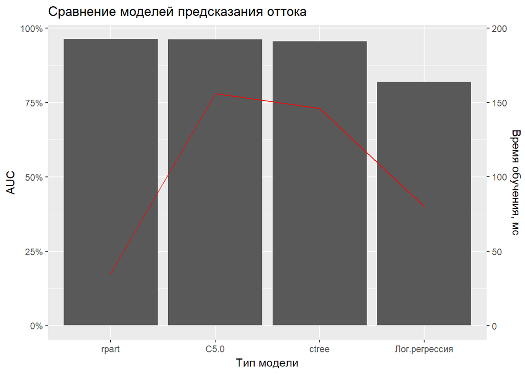

```r
turnover_bench %>%
  getBMRAggrPerformances(as.df = TRUE) %>%
  arrange(desc(auc.test.mean)) %>%
  ggplot(aes(x = fct_inorder(learner.id))) +
           geom_bar(aes(y = auc.test.mean), stat = "identity") +
           geom_line(aes(y = timetrain.test.mean * 5, group = 1),
                     colour = "red") +
  scale_y_continuous(sec.axis = sec_axis(~ . * 1000 / 5,
                                         name = "Время обучения, мс"),
                     labels = scales::percent) +
    labs(title = "Сравнение моделей предсказания оттока",
       x = "Тип модели", y = "AUC")
```

Сравним поведение алгоритмов (разделяющие поверхности) в пространстве двух предикторов - уровень удовлетворенности и загруженность сотрудников:

```
## $Лог.регрессия
```

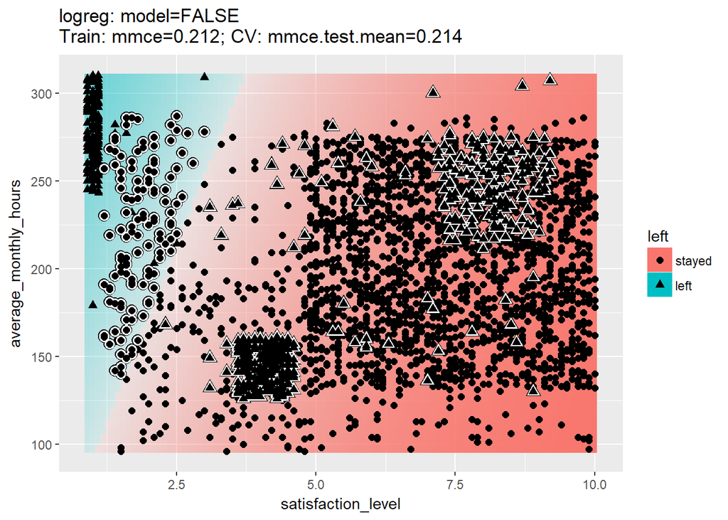

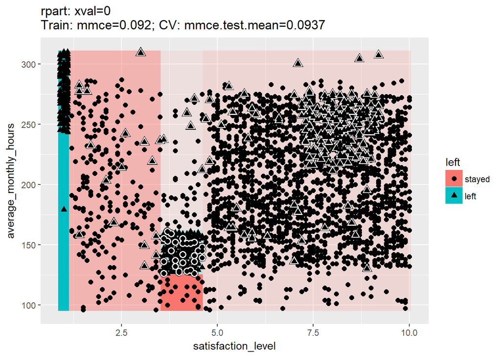

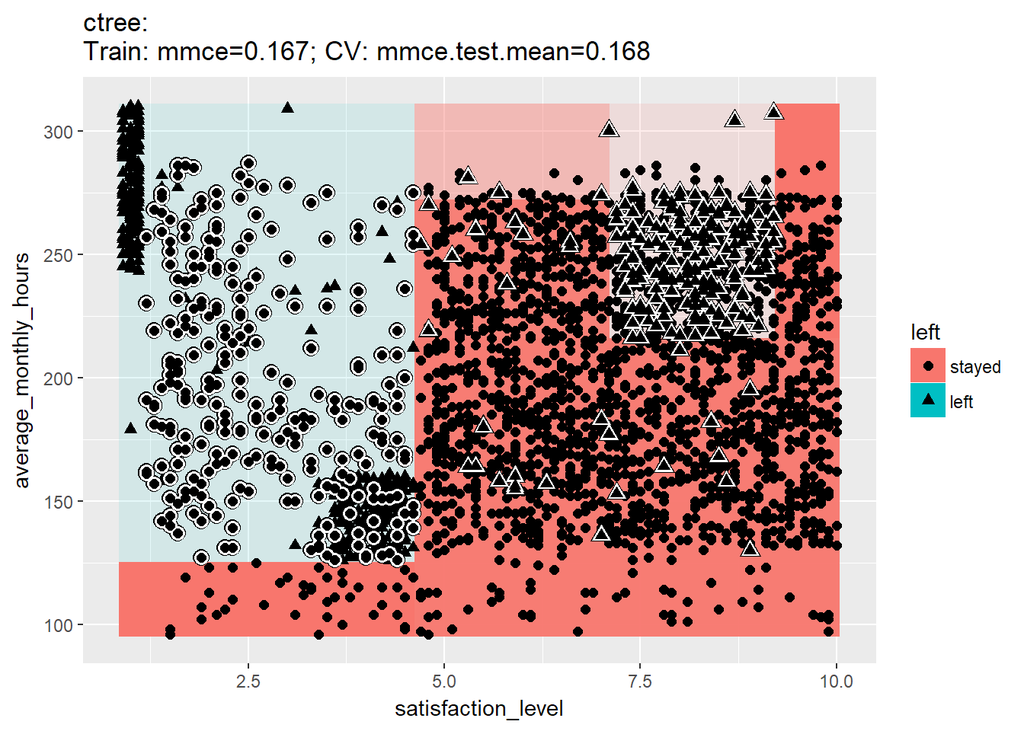

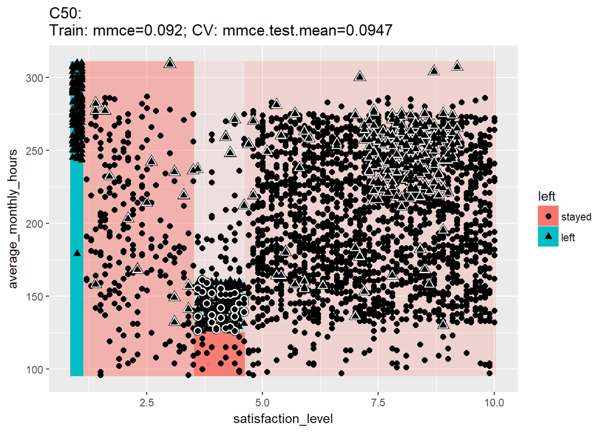

```r
turnover_learners %>%
  lapply(plotLearnerPrediction, task = turnover_task,
         features = c("satisfaction_level",
                      "average_monthly_hours"))
```

## Исследование модели классификации

Извлечем из списка обученный классификатор rpart, показавший неплохую точность и наибольшую скорость работы.

```r
turnover_rpart <- turnover_learners$rpart
turnover_rpart
```

```
## Learner rpart from package rpart
## Type: classif
## Name: Decision Tree; Short name: rpart
## Class: classif.rpart
## Properties: twoclass,multiclass,missings,numerics,factors,ordered,prob,weights,featimp
## Predict-Type: prob
## Hyperparameters: xval=0
```

Для построения ROC-кривых потребуется сделать прогноз по модели на тестовых данных. Для этого разобъем задачу `turnover_task` на обучающую и тестовую подвыборки.

```r
set.seed(123)
# Количество наблюдений в задаче
turnover_n <- getTaskSize(turnover_task)

# Индексы строк в обучающей и тестовой подвыборках
turnover_train <- sample(turnover_n, size = 0.7 * turnover_n)
turnover_test <- setdiff(1:turnover_n, turnover_train)
```

Обучаем модель на обучающей выборке и строим прогноз на тестовой:

```r
turnover_m_rpart <- train(learner = turnover_rpart,
                          task = turnover_task,
                          subset = turnover_train)

turnover_pr_rpart <- predict(turnover_m_rpart,
                             task = turnover_task,
                             subset = turnover_test)
```

Посмотрим на полученное дерево решений:

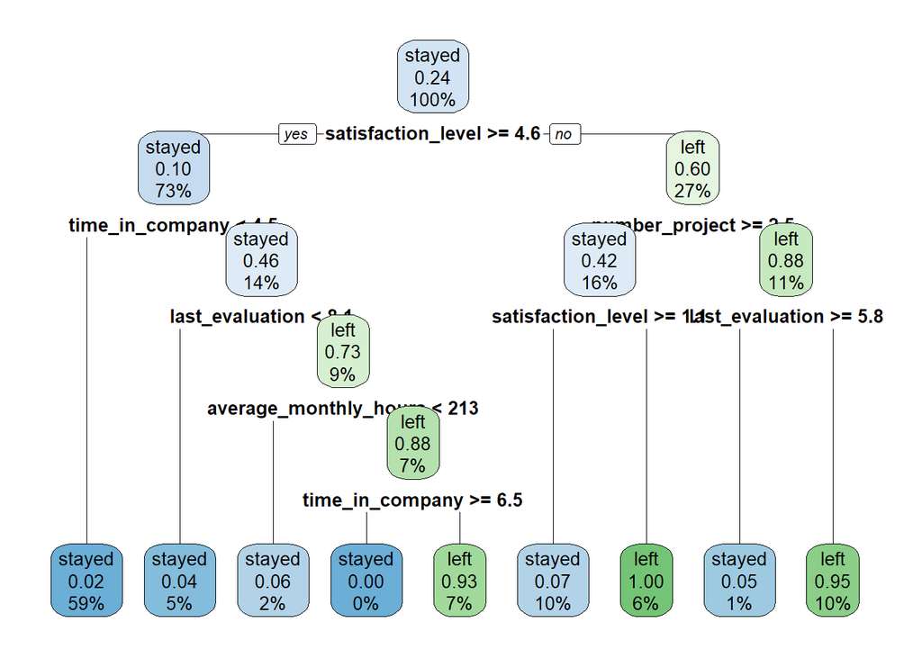

```r
rpart.plot(getLearnerModel(turnover_m_rpart), tweak = 1.2)
```

Оценка ошибки классификатора на тестовой выборке:

```r
performance(turnover_pr_rpart,
            measures = clas_ms) %>%
  round(4)
```

```
##    auc  kappa   mmce    tpr    tnr    fpr
## 0.9660 0.8991 0.0344 0.9095 0.9815 0.0185
```

В зависимости от выбранного порога отсечения, будет меняться чувствительность и специфичность классификатора.

Текущий порог равен 50%:

```r
turnover_pr_rpart$threshold
```

```
## stayed   left
##    0.5    0.5
```

При необходимости, можно изменить порог классификации при помощи функции `setThreshold()`.

Для построения ROC-кривой, необходимо сгенерировать зависимость показателей ошибки от порога - при помощи функции `generateThreshVsPerfData()`. Первыми в списке показателей должны следовать FPR и TPR, т.к. именно по ним строится ROC-кривая.

После этого можно визуализировать полученный объект с помощью функции `plotThreshVsPerf()`:

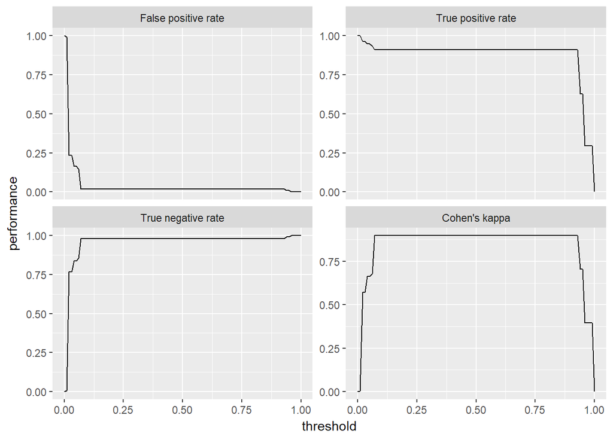

```r
turnover_roc <- generateThreshVsPerfData(turnover_pr_rpart,
                         measures = list(fpr, tpr, tnr, kappa))
plotThreshVsPerf(turnover_roc)
```

По этим же данным строится ROC-кривая:

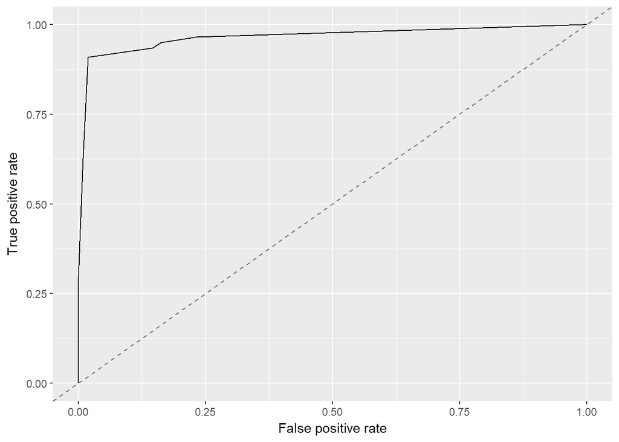

```r
plotROCCurves(turnover_roc)
```

Матрицу ошибок классификации можно получить с помощью функции `calculateConfusionMatrix()`:

```r
calculateConfusionMatrix(turnover_pr_rpart)
```

```
##         predicted
## true     stayed left -err.-
##   stayed    688   13     13
##   left       18  181     18
##   -err.-     18   13     31
```

При необходимости, можно вычислить относительные частоты ошибок разного вида:

```r
calculateConfusionMatrix(turnover_pr_rpart, relative = T)
```

```
## Relative confusion matrix (normalized by row/column):
##         predicted
## true     stayed    left      -err.-
##   stayed 0.98/0.97 0.02/0.07 0.02
##   left   0.09/0.03 0.91/0.93 0.09
##   -err.-      0.03      0.07 0.03
##
##
## Absolute confusion matrix:
##         predicted
## true     stayed left -err.-
##   stayed    688   13     13
##   left       18  181     18
##   -err.-     18   13     31
```

Чтобы сравнить сразу несколько моделей, можно воспользоваться функцией для обработки списков `lapply()`:

```r
turnover_models <-
  turnover_learners %>%
  lapply(train, task = turnover_task, subset = turnover_train)

turnover_predictions <-
  turnover_models %>%
  lapply(predict, task = turnover_task, subset = turnover_test)
```

Функция для подготовки данных для ROC-кривой может обрабатывать списки самостоятельно:

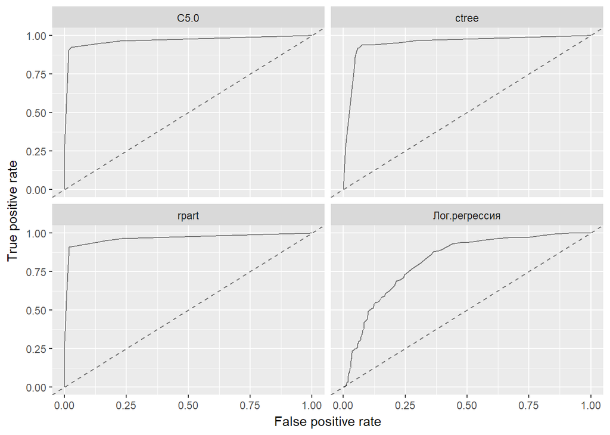

```r
turnover_roc2 <-
  generateThreshVsPerfData(turnover_predictions,
                           measures = list(fpr, tpr))

plotROCCurves(turnover_roc2)
```

Как правило, удобнее сравнивать ROC-кривые, наложив их на один график. Для получения такой визуализации можно применить `ggplot()` к таблице данных, которая хранится внутри объекта, созданного на предыдущем шаге:

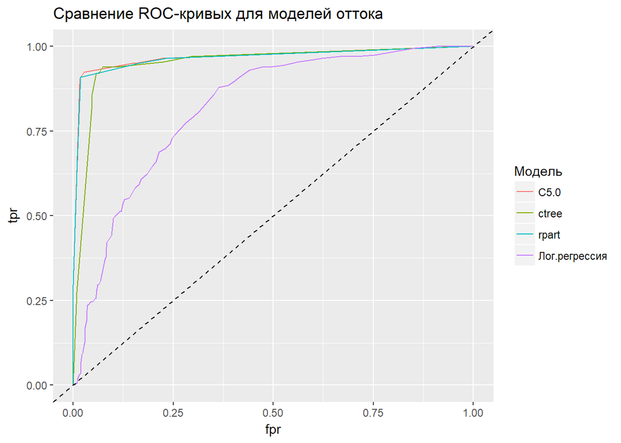

```r
turnover_roc2$data %>%
  ggplot(aes(fpr, tpr, colour = learner)) +
  geom_path() +
  geom_abline(slope = 1, linetype = "dashed") +
  labs(title = "Сравнение ROC-кривых для моделей оттока",
       colour = "Модель")
```

Лучший результат - у моделей rpart и C5.0.

См. также https://mlr-org.github.io/mlr-tutorial/release/html/roc_analysis/index.html

## Оптимизация гиперпараметров модели

Большинство алгоритмов машинного обучения содержат **гиперпараметры** - настройки, влияющие на процесс обучения модели. Например, для дерева решений rpart, доступны гиперпараметры: - `minsplit` - минимальное число наблюдений в узле для дальнейшего разбиения,  
- `cp` - параметр сложности дерева - минимальное улучшение меры чистоты при разбиении, при котором оно осуществляется; чем меньше `cp`, тем сильнее “разрастается” дерево

Получить список гиперпараметров алгоритма обучения можно при помощи функции `getParamSet()`:

```r
getParamSet(turnover_rpart)
```

```
##                    Type len  Def   Constr Req Tunable Trafo
## minsplit        integer   -   20 1 to Inf   -    TRUE     -
## minbucket       integer   -    - 1 to Inf   -    TRUE     -
## cp              numeric   - 0.01   0 to 1   -    TRUE     -
## maxcompete      integer   -    4 0 to Inf   -    TRUE     -
## maxsurrogate    integer   -    5 0 to Inf   -    TRUE     -
## usesurrogate   discrete   -    2    0,1,2   -    TRUE     -
## surrogatestyle discrete   -    0      0,1   -    TRUE     -
## maxdepth        integer   -   30  1 to 30   -    TRUE     -
## xval            integer   -   10 0 to Inf   -   FALSE     -
## parms           untyped   -    -        -   -    TRUE     -
```

Для каждого гиперпараметра указан тип, значение по умолчанию, диапазон изменения и возможность настройки.

Чтобы оптимизировать гиперпараметры, необходимо создать описание набора параметров для при помощи функции `makeParamSet()`, указав для каждого гиперпараметра тип и диапазон изменения.

```r
ps_rpart = makeParamSet(
  makeNumericParam("cp", lower = -4, upper = -2,
                   trafo = function(x) 10^x),
  makeIntegerParam("minsplit", lower = 4, upper = 50))
```

Параметр `trafo` функции makeNumericParam() позволяет задать функцию преобразования (transform) для гиперпараметра. В этом примере мы задали для гиперпараметра `cp` диапазон изменения от -4 до -2 в линейной шкале, однако в алгоритме обучения будут использоваться значения от $10^{-4}$ до $10^{-2}$ с шагом в один порядок, т.к. мы используем функцию преобразования: $10^x$.

Чем больше гиперпараметров в наборе и число возможных значений каждого параметра, тем дольше будет проводиться поиск оптимального сочетания.

Доступны несколько алгоритмов оптимизации параметров (см. http://mlr-org.github.io/mlr-tutorial/release/html/tune/index.html).

Наиболее простым (и долгим) является перебор всех сочетаний `makeTuneControlGrid()`. Быстрее, но без гарантий, работает алгоритм случайного перебора `makeTuneControlRandom()`. В этом примере мы используем алгоритм имитации отжига, который сочетает направленный перебор и случайный поиск - `makeTuneControlGenSA()`.

```r
# Инициализация генератора СЧ
set.seed(123, "L'Ecuyer")

# Выбор алгоритма оптимизации
control_rpart = makeTuneControlGenSA(budget = 300)

# Выбор стратегии ресэмплинга
cv_rdesc = makeResampleDesc("CV", iters = 5) # 10 блоков - надежнее, но дольше

# Оптимизация гиперпараметров
parallelStartSocket(num_cores)

res_rpart = tuneParams(turnover_rpart,
                       measures = auc,
                       task = turnover_task,
                       control = control_rpart,
                       resampling = cv_rdesc,
                       par.set = ps_rpart,
                       show.info = FALSE)

parallelStop()
```

Оптимальное сочетание гиперпараметров:

```r
print(res_rpart)
```

```
## Tune result:
## Op. pars: cp=0.0021; minsplit=17
## auc.test.mean=0.965
```

Зависимость AUC от значений гиперпараметров можно визуализировать:

```
## geom_path: Each group consists of only one observation. Do you need to
## adjust the group aesthetic?
## geom_path: Each group consists of only one observation. Do you need to
## adjust the group aesthetic?
```

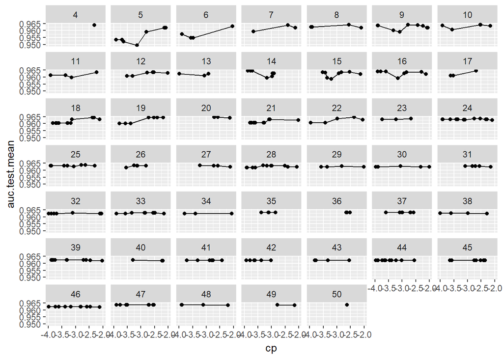

```r
generateHyperParsEffectData(res_rpart) %>%
  plotHyperParsEffect(x = "cp", y = "auc.test.mean",
                      plot.type = "line",
                      #z = "minsplit",
                      facet = "minsplit")
```

По графикам видно, что при большем минимальном размере узла для разбиения зависимость AUC от параметра сложности cp слабо выражена. Если разрешить маленькие узлы, то зависимость становится более выраженной, т.к. при малом значении `cp` модель переобучается и ее качество на тестовой выборке падает.

Также можно получить тепловую карту для значения целевого показателя в зависимости от двух гиперпараметров:

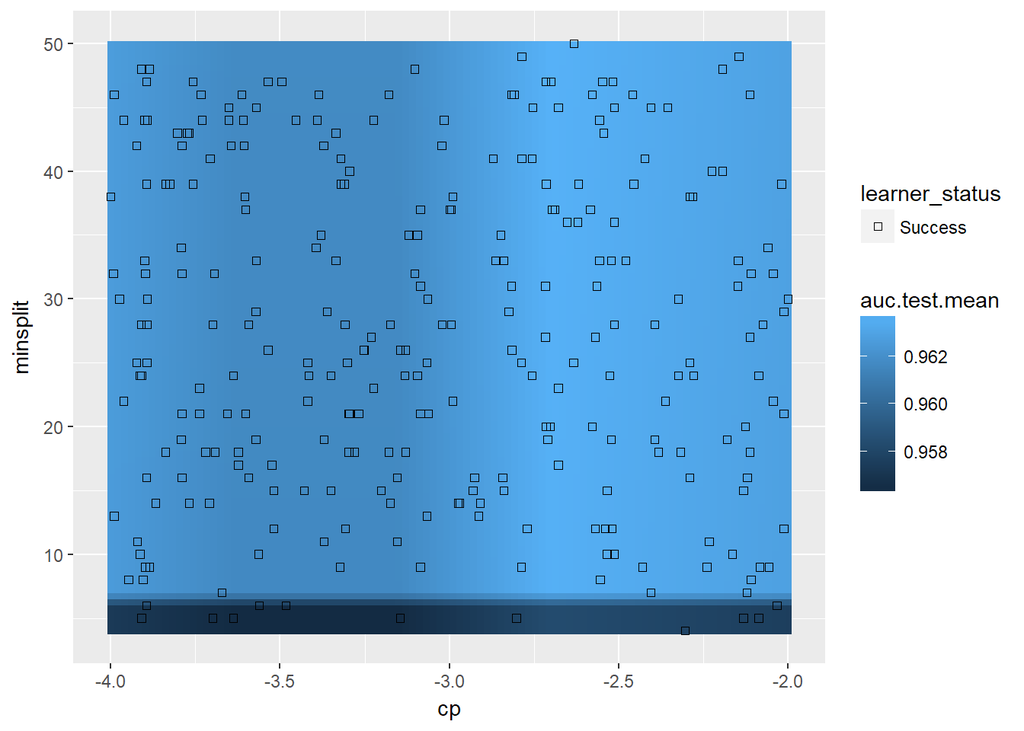

```r
generateHyperParsEffectData(res_rpart) %>%
  plotHyperParsEffect(x = "cp", y = "minsplit",
                      z = "auc.test.mean",
                      plot.type = "heatmap",
                      interpolate = "regr.earth",
                      show.experiments = TRUE)
```

См. также http://mlr-org.github.io/Exploring-and-Understanding-Hyperparameter-Tuning/

```r
# Описание алгоритма обучения
turnover_rpart_opt <-  makeLearner("classif.rpart",
                                   predict.type = "prob",
                                   par.vals =
                                     list(cp = 10^(-2.7),
                                          minsplit = 25))
# Обучение модели
m_rpart_opt <- train(turnover_rpart_opt,
                     task = turnover_task,
                     subset = turnover_train)

# Прогнозирование (на тестовой выборке)
pr_rpart_opt <- predict(m_rpart_opt, task = turnover_task,
                        subset = turnover_test)
```

Сравним оптимизированную модель с первоначальной

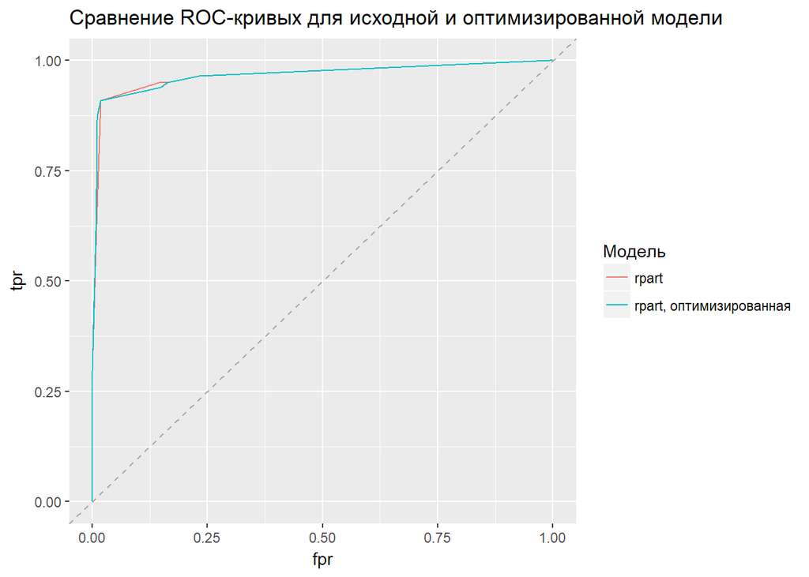

```r
# Получение данных для ROC-кривых
turnover_rpart_compare <-
  generateThreshVsPerfData(
    list("rpart" = turnover_predictions$rpart,
         "rpart, оптимизированная" = pr_rpart_opt),
    measures = list(fpr, tpr))

# Сравнение ROC-кривых
turnover_rpart_compare$data %>%
  ggplot(aes(x = fpr, y = tpr, color = learner)) +
  geom_path() +
  geom_abline(slope = 1, linetype = "dashed",
              color = "darkgray") +
  labs(title = "Сравнение ROC-кривых для исходной и оптимизированной модели",
       colour = "Модель")
```

Улучшение есть, но минимальное.

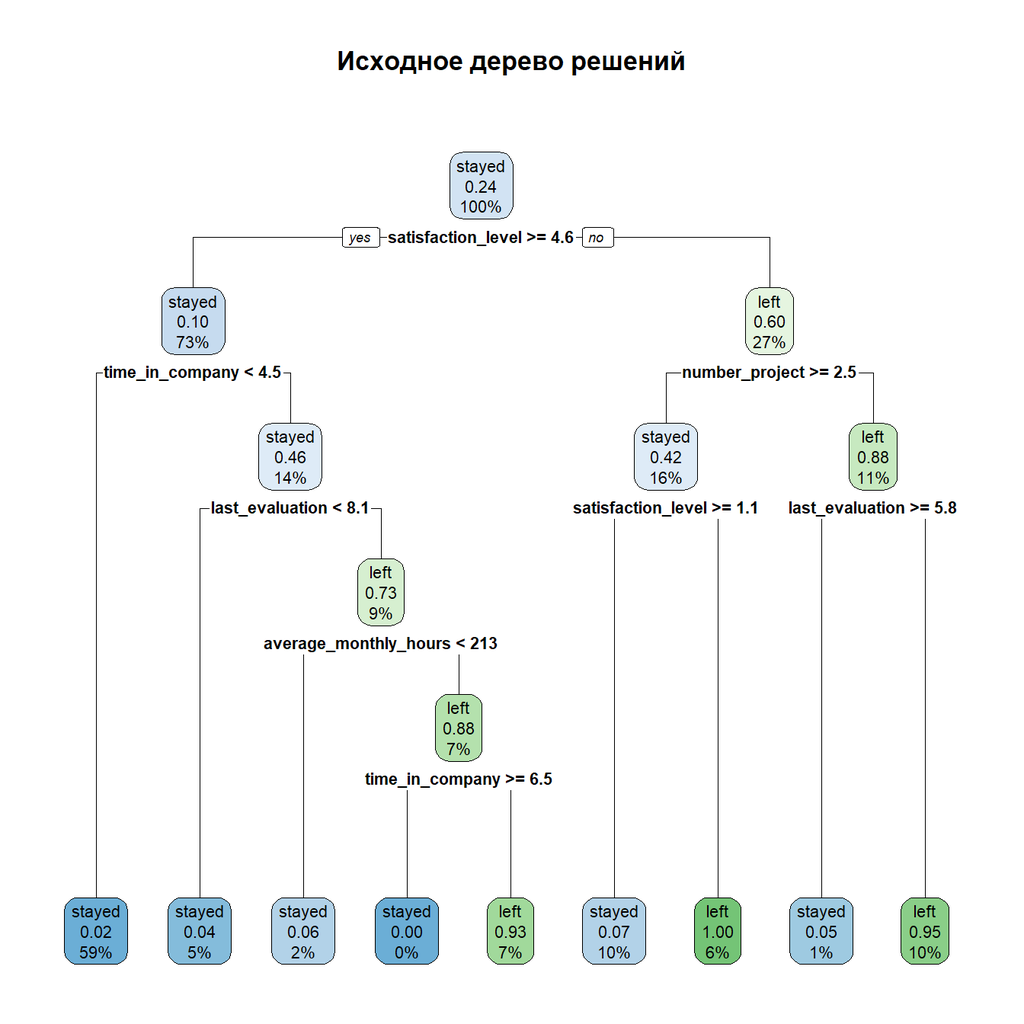

```r
# Исходная модель
getLearnerModel(turnover_m_rpart) %>%
  rpart.plot(main = "Исходное дерево решений")
```